# R Notebook

Kai Ren Chen

# BCB420 Assignment 1 Report: Data set selection and initial Processing (Journal Article Title: Gene therapy of dominant CRX-Leber congenital amaurosis using patient retinal organoids)

## Part 1: Selecting the Data

if the geo meta sqlite database has not been downloaded, download it

```r
if (!file.exists('GEOmetadb.sqlite')) {
    GEOmetadb::getSQLiteFile()
}
```

This is the SQL query that I used to search for, a few thing that are different from code given in lecture, I only select those with a PubMed id to ensure there is a publication associated with the dataset, and where the supplementary file is like “count” to ensure it does not just have a raw file, and it is not connected with cancer, tumor, or stem cell, and SARS-CoV-2, but is connected to gene therapy

```r
con <- DBI::dbConnect(RSQLite::SQLite(),'GEOmetadb.sqlite')

sql <- paste("SELECT DISTINCT gse.title, gse.gse, gse.supplementary_file, gse.pubmed_id, gpl.title
              FROM gse
              INNER JOIN gse_gpl ON gse.gse = gse_gpl.gse
              INNER JOIN gpl ON gse_gpl.gpl = gpl.gpl
              WHERE gpl.technology = 'high-throughput sequencing'
              AND gpl.organism = 'Homo sapiens'
              AND gse.pubmed_id is NOT NULL
              AND gse.submission_date > '2015-01-01'
              AND gse.supplementary_file is NOT NULL
              AND gse.supplementary_file LIKE '%count%'
              AND gse.title NOT LIKE '%cancer%'
              AND gse.title NOT LIKE '%tumor%'
              AND gse.title NOT LIKE '%stem cells%'
              AND gse.title NOT LIKE '%SARS-CoV-2%'
              AND gse.title LIKE '%gene therapy%'")

queryResults <- DBI::dbGetQuery(con, sql)
queryResults
```

| title | gse | supplementary_file | pubmed_id | title |
| --- | --- | --- | --- | --- |
| Lentiviral CRISPR Epigenome Editing of Inflammatory Receptors as a Gene Therapy Strategy for Disc Degeneration | GSE132958 | ftp://ftp.ncbi.nlm.nih.gov/geo/series/GSE132nnn/GSE132958/suppl/GSE132958_normalizedCounts_farhang_humanGeneTherapy_2019.tsv.gz;\tftp://ftp.ncbi.nlm.nih.gov/geo/series/GSE132nnn/GSE132958/suppl/GSE132… | 31140325 | Illumina HiSeq 2500 (Homo sapiens) |
| Gene therapy of dominant CRX-Leber congenital amaurosis using patient retinal organoids I | GSE152939 | ftp://ftp.ncbi.nlm.nih.gov/geo/series/GSE152nnn/GSE152939/suppl/GSE152939_I138fs_norm_counts_5CPM.txt.gz;\tftp://ftp.ncbi.nlm.nih.gov/geo/series/GSE152nnn/GSE152939/suppl/GSE152939_I138fs_raw_counts.t… | 33513359 | Illumina HiSeq 2500 (Homo sapiens) |

```r
DBI::dbDisconnect(con)
```

and there was only 2, and I chose the one on LCA.

## Part 2: Downloading the Data

With GEOquery, I download the GEO series as an R object and look at some attributes of it

```r
queryResults <- 0
gse <- GEOquery::getGEO("GSE152939", GSEMatrix=FALSE)
```

```r
knitr::kable(data.frame(head(GEOquery::Meta(gse))), format = "html")
```

| contact_address | contact_city | contact_country | contact_department | contact_email | contact_institute |
| --- | --- | --- | --- | --- | --- |
| 6 Center Dr Bldg 6, Rm 303 | Bethesda | USA | NEI | zachary.batz@nih.gov | NIH |

With GEOquery, aftering checking if I do have the file that I want, I also downloaded the supplementary files of the data series I am interested in

```r
if (!file.exists("/home/rstudio/projects/GSE152939/GSE152939_I138fs_raw_counts.txt.gz")) {
  supplementaryFiles <- GEOquery::getGEOSuppFiles('GSE152939')
} else {
  supplementaryFiles <- data.frame(row = c(1, 2, 3, 4))
  rownames(supplementaryFiles) <- c(
      "/home/rstudio/projects/GSE152939/GSE152939_I138fs_norm_counts_5CPM.txt.gz",
      "/home/rstudio/projects/GSE152939/GSE152939_I138fs_raw_counts.txt.gz",
      "/home/rstudio/projects/GSE152939/GSE152939_K88N_norm_counts_5CPM.txt.gz",
      "/home/rstudio/projects/GSE152939/GSE152939_K88N_raw_counts.txt.gz"
    )
}
```

## Part 3: Inspecting Data

```r
filenames <- rownames(supplementaryFiles)
filenames
```

```
[1] "/home/rstudio/projects/GSE152939/GSE152939_I138fs_norm_counts_5CPM.txt.gz"
[2] "/home/rstudio/projects/GSE152939/GSE152939_I138fs_raw_counts.txt.gz"
[3] "/home/rstudio/projects/GSE152939/GSE152939_K88N_norm_counts_5CPM.txt.gz"
[4] "/home/rstudio/projects/GSE152939/GSE152939_K88N_raw_counts.txt.gz"
```

We can see that the first and third supplementary file is normalized counts, and the second and fourth files is raw count. We are using raw count, as per specified, and since there are 2 files (which are 2 different part of the study) I choose the second file due to numerical order.

```r
supplementaryFiles <- 0
read.table(filenames[2],header=TRUE,
           check.names=FALSE,nrows = 1)[1,1:25]
```

|  | ens.id | gene.id | Control_d125_1 | Control_d125_2 | Control_d125_3 | CRXLCA_d125_1 | CRXLCA_d125_2 | CRXLCA_d125_3 | Control_d90_1 | Control_d90_2 | Control_d90_3 | CRXLCA_d90_1 | CRXLCA_d90_2 | CRXLCA_d90_3 | Control_d150_1 | Control_d150_2 | Control_d150_3 | CRXLCA_d150_1 | CRXLCA_d150_2 | CRXLCA_d150_3 | Control_d200_1 | Control_d200_2 | Control_d200_3 | Control_d200_4 | CRXLCA_d200_1 |
| --- | --- | --- | --- | --- | --- | --- | --- | --- | --- | --- | --- | --- | --- | --- | --- | --- | --- | --- | --- | --- | --- | --- | --- | --- | --- |
| 1 | ENSG00000000003 | TSPAN6 | 1573.214 | 1923.794 | 1278.986 | 1317.265 | 1620.322 | 1170.522 | 1864.038 | 2086.618 | 2199.28 | 2257.944 | 1788.651 | 1972.641 | 2737.74 | 2496.584 | 1919.875 | 1706.329 | 1634.949 | 1581.506 | 1902.939 | 1846.511 | 1770.476 | 1620.798 | 1089.474 |

```r
read.table(filenames[2],header=TRUE,
           check.names=TRUE,nrows = 1)[1,1:25]
```

|  | ens.id | gene.id | Control_d125_1 | Control_d125_2 | Control_d125_3 | CRXLCA_d125_1 | CRXLCA_d125_2 | CRXLCA_d125_3 | Control_d90_1 | Control_d90_2 | Control_d90_3 | CRXLCA_d90_1 | CRXLCA_d90_2 | CRXLCA_d90_3 | Control_d150_1 | Control_d150_2 | Control_d150_3 | CRXLCA_d150_1 | CRXLCA_d150_2 | CRXLCA_d150_3 | Control_d200_1 | Control_d200_2 | Control_d200_3 | Control_d200_4 | CRXLCA_d200_1 |
| --- | --- | --- | --- | --- | --- | --- | --- | --- | --- | --- | --- | --- | --- | --- | --- | --- | --- | --- | --- | --- | --- | --- | --- | --- | --- |
| 1 | ENSG00000000003 | TSPAN6 | 1573.214 | 1923.794 | 1278.986 | 1317.265 | 1620.322 | 1170.522 | 1864.038 | 2086.618 | 2199.28 | 2257.944 | 1788.651 | 1972.641 | 2737.74 | 2496.584 | 1919.875 | 1706.329 | 1634.949 | 1581.506 | 1902.939 | 1846.511 | 1770.476 | 1620.798 | 1089.474 |

There is no difference between checking names or not, since this dataset does not use negative and positive signs to represent control and test.

This is what the raw count file looks like, we can see that it has 26 samples. 6 sample for each of day 90, day 125, day 150, and 8 samples for day 200.

```r
CRX_ExperimentRawCount <- read.delim(filenames[2], header=TRUE, check.names = FALSE)
knitr::kable(CRX_ExperimentRawCount[1:10,1:28], format = "html")
```

| ens.id | gene.id | Control_d125_1 | Control_d125_2 | Control_d125_3 | CRXLCA_d125_1 | CRXLCA_d125_2 | CRXLCA_d125_3 | Control_d90_1 | Control_d90_2 | Control_d90_3 | CRXLCA_d90_1 | CRXLCA_d90_2 | CRXLCA_d90_3 | Control_d150_1 | Control_d150_2 | Control_d150_3 | CRXLCA_d150_1 | CRXLCA_d150_2 | CRXLCA_d150_3 | Control_d200_1 | Control_d200_2 | Control_d200_3 | Control_d200_4 | CRXLCA_d200_1 | CRXLCA_d200_2 | CRXLCA_d200_3 | CRXLCA_d200_4 |
| --- | --- | --- | --- | --- | --- | --- | --- | --- | --- | --- | --- | --- | --- | --- | --- | --- | --- | --- | --- | --- | --- | --- | --- | --- | --- | --- | --- |
| ENSG00000000003 | TSPAN6 | 1573.21369 | 1923.79440 | 1278.98610 | 1317.265000 | 1620.3219 | 1170.5217 | 1864.03820 | 2086.618100 | 2199.28042 | 2257.9440 | 1788.650640 | 1972.6406 | 2737.740440 | 2496.5839 | 1919.8747 | 1706.329030 | 1634.94947 | 1581.5060 | 1902.9390 | 1846.5109 | 1770.4760 | 1620.7981 | 1089.47390 | 1244.4737 | 1341.5173 | 1257.8638 |
| ENSG00000000005 | TNMD | 6.00000 | 2.00000 | 1.00000 | 2.000000 | 2.0000 | 9.0000 | 6.00000 | 0.000000 | 6.00000 | 0.0000 | 4.999998 | 0.0000 | 6.000000 | 2.0000 | 4.0000 | 5.000000 | 2.00000 | 0.0000 | 5.0000 | 1.0000 | 4.0000 | 6.0000 | 0.00000 | 2.0000 | 0.0000 | 2.0000 |
| ENSG00000000419 | DPM1 | 487.99970 | 620.00050 | 589.99960 | 595.999900 | 608.0002 | 560.9997 | 526.99982 | 524.999700 | 830.00057 | 697.9996 | 613.000100 | 691.9996 | 1443.998700 | 1034.0001 | 788.9996 | 952.000090 | 832.00004 | 802.0007 | 652.9999 | 697.9998 | 638.9997 | 625.0000 | 636.00099 | 626.0003 | 668.9996 | 642.0003 |
| ENSG00000000457 | SCYL3 | 470.92767 | 558.03740 | 465.24850 | 563.752700 | 670.8157 | 536.9271 | 402.49360 | 467.287800 | 677.16720 | 603.9019 | 559.245400 | 629.8577 | 1054.507800 | 897.0788 | 615.1597 | 690.786027 | 637.24368 | 738.7893 | 353.0338 | 320.7823 | 355.0521 | 339.0006 | 359.75706 | 361.5495 | 333.2544 | 358.9647 |
| ENSG00000000460 | C1orf112 | 212.39300 | 268.48910 | 234.02950 | 258.535820 | 333.4486 | 268.9040 | 233.92044 | 249.958850 | 305.50928 | 362.7412 | 385.278710 | 363.2271 | 414.115280 | 478.9368 | 375.4047 | 399.329760 | 369.76560 | 374.3401 | 177.0091 | 154.8951 | 142.7873 | 198.3717 | 174.68292 | 210.3309 | 194.7030 | 197.4378 |
| ENSG00000000938 | FGR | 4.00000 | 4.00000 | 4.00000 | 0.000000 | 2.0000 | 1.0000 | 2.00000 | 2.999995 | 2.00000 | 0.0000 | 2.999998 | 1.0000 | 4.999999 | 3.0000 | 6.0000 | 3.999999 | 3.00000 | 6.0000 | 1.0000 | 3.0000 | 3.0000 | 0.0000 | 1.00000 | 1.0000 | 0.0000 | 1.0000 |
| ENSG00000000971 | CFH | 88.21349 | 30.99999 | 51.06442 | 8.450928 | 30.0023 | 51.5743 | 14.01726 | 5.444810 | 7.43978 | 5.0000 | 10.346342 | 24.0000 | 140.727700 | 107.8156 | 177.7637 | 49.000030 | 8.03806 | 220.0003 | 619.7189 | 569.8673 | 1009.4347 | 975.6587 | 84.99997 | 351.6143 | 115.4903 | 188.0000 |
| ENSG00000001036 | FUCA2 | 511.71039 | 617.67016 | 507.69808 | 503.170900 | 775.8995 | 545.9450 | 819.12160 | 712.214420 | 911.65140 | 1144.3464 | 1081.991980 | 947.7342 | 1496.017250 | 959.7734 | 889.0201 | 752.154900 | 800.52728 | 594.2613 | 624.0179 | 490.0000 | 711.0389 | 696.9997 | 511.00004 | 608.0824 | 652.0004 | 885.0000 |
| ENSG00000001084 | GCLC | 1113.54382 | 1241.39523 | 1016.31601 | 1307.938110 | 1329.4989 | 1101.1362 | 1001.30400 | 986.522279 | 1268.72373 | 1304.7203 | 1266.898960 | 1218.6999 | 2659.310670 | 2638.8558 | 2091.0089 | 2188.294254 | 1982.77891 | 1877.7475 | 1429.0974 | 1464.3152 | 1530.8722 | 1442.0988 | 1080.05336 | 1218.0008 | 1155.0019 | 1415.0243 |
| ENSG00000001167 | NFYA | 1549.00400 | 1793.00200 | 1499.00100 | 1896.005000 | 1803.0040 | 1680.0040 | 1600.00400 | 1734.002000 | 2268.00000 | 2325.9970 | 2261.002000 | 2321.9950 | 2531.995000 | 2508.0000 | 1922.0040 | 2541.002000 | 2454.97900 | 2355.9980 | 1631.0020 | 1646.9960 | 1692.9970 | 1587.0030 | 1713.00300 | 1765.0040 | 1778.9980 | 1727.9990 |

## Part 4: Looking at Duplicates in Data

There is this many gene ids across the samples

```r
dim(CRX_ExperimentRawCount)
```

```
[1] 57579    28
```

the expression data’s column names

```r
colnames(CRX_ExperimentRawCount)
```

```
 [1] "ens.id"         "gene.id"        "Control_d125_1" "Control_d125_2"
 [5] "Control_d125_3" "CRXLCA_d125_1"  "CRXLCA_d125_2"  "CRXLCA_d125_3"
 [9] "Control_d90_1"  "Control_d90_2"  "Control_d90_3"  "CRXLCA_d90_1"
[13] "CRXLCA_d90_2"   "CRXLCA_d90_3"   "Control_d150_1" "Control_d150_2"
[17] "Control_d150_3" "CRXLCA_d150_1"  "CRXLCA_d150_2"  "CRXLCA_d150_3"
[21] "Control_d200_1" "Control_d200_2" "Control_d200_3" "Control_d200_4"
[25] "CRXLCA_d200_1"  "CRXLCA_d200_2"  "CRXLCA_d200_3"  "CRXLCA_d200_4"
```

the number of times each genes appears (note, not ensemble id)

```r
summarized_gene_counts <- sort(table(CRX_ExperimentRawCount$gene.id), decreasing = TRUE)
summarized_gene_counts
```

[output not shown]

[output cut: 346 more lines]

[output not shown]

Most of the gene ids that have more than one appearance, are RF, which I believe are non-coding RNA

```r
knitr::kable(summarized_gene_counts[which(summarized_gene_counts>1)])
```

| Var1 | Freq |
| --- | --- |
| RF00019 | 756 |
| RF00017 | 169 |
| RF00012 | 51 |
| RF02271 | 36 |
| RF00026 | 33 |
| RF01210 | 31 |
| RF00156 | 27 |
| RF00322 | 26 |
| RF00096 | 22 |
| RF00004 | 19 |
| RF00561 | 19 |
| RF00402 | 18 |
| RF00003 | 13 |
| RF00432 | 12 |
| RF00554 | 11 |
| RF00568 | 10 |
| RF01518 | 9 |
| RF00092 | 8 |
| RF00015 | 7 |
| RF00066 | 7 |
| RF00100 | 7 |
| RF00139 | 7 |
| RF00272 | 7 |
| RF00425 | 7 |
| RF00072 | 6 |
| RF00091 | 6 |
| RF00181 | 6 |
| RF00275 | 6 |
| RF00284 | 6 |
| RF00601 | 6 |

[output cut: 142 more lines]

if we do ensemble id instead, they are unique

```r
summarized_ens_counts <- sort(table(CRX_ExperimentRawCount$ens.id), decreasing = TRUE)
summarized_ens_counts
```

[output not shown]

```r
summarized_gene_counts <- 0
summarized_ens_counts <- 0
```

## Part 5: Filtering out Data with low count

```r
# first get the count of each gene per a million bases
countPerMillion <- edgeR::cpm(CRX_ExperimentRawCount[3:28])
rownames(countPerMillion) <- CRX_ExperimentRawCount[,1]
```

I have 3 (or 4 for one condition, the day 200 one) biological replicate, so n = 3

```r
keep = rowSums(countPerMillion >1) >= 3
CRX_ExperimentRawCountFiltered <- CRX_ExperimentRawCount[keep,]
CRX_ExperimentRawCount <- 0
countPerMillion <- 0
keep <- 0
```

```r
summarized_gene_counts <- sort(table(CRX_ExperimentRawCountFiltered$gene.id), decreasing = TRUE)
knitr::kable(summarized_gene_counts[which(summarized_gene_counts>1)], format = 'html')
```

| Var1 | Freq |
| --- | --- |
| RNA5-8SN2 | 4 |
| RF00017 | 3 |
| ATXN7 | 2 |
| BMS1P4 | 2 |
| CCDC39 | 2 |
| CYB561D2 | 2 |
| ELFN2 | 2 |
| HSPA14 | 2 |
| IPO5P1 | 2 |
| LINC01238 | 2 |
| MATR3 | 2 |
| PKD1P1 | 2 |
| POLR2J3 | 2 |
| POLR2J4 | 2 |
| RF00019 | 2 |
| RGS5 | 2 |
| TBCE | 2 |
| TMSB15B | 2 |
| ZNF883 | 2 |

```r
summarized_gene_counts <- 0
```

```r
dim(CRX_ExperimentRawCountFiltered)
```

[output not shown]

## part 5: Plotting of Data before Normalization

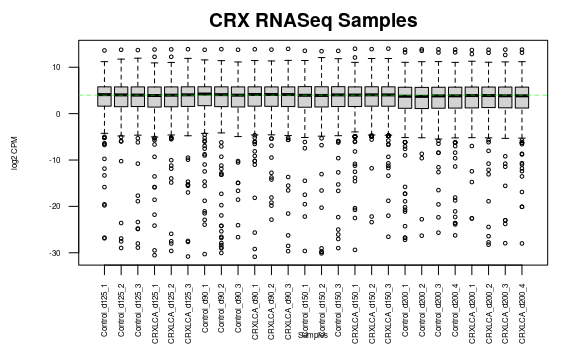

```r
data2plot <- log2(edgeR::cpm(CRX_ExperimentRawCountFiltered[,3:28]))
boxplot(data2plot, xlab = "Samples", ylab = "log2 CPM",
        las = 2, cex = 0.5, cex.lab = 0.5,
        cex.axis = 0.5, main = "CRX RNASeq Samples")
#draw the median on each box plot
abline(h = median(apply(data2plot, 2, median)),
       col = "green", lwd = 0.6, lty = "dashed")
```

```r
dim(CRX_ExperimentRawCountFiltered)
```

```
[1] 19422    28
```

```r
counts_density <- apply(log2(edgeR::cpm(CRX_ExperimentRawCountFiltered[,3:28])),
                        2, density)
  #calculate the limits across all the samples
xlim <- 0; ylim <- 0
for (i in 1:length(counts_density))
  {
    xlim <- range(c(xlim, counts_density[[i]]$x));
    ylim <- range(c(ylim, counts_density[[i]]$y))
  }
cols <- rainbow(length(counts_density))
ltys <- rep(1, length(counts_density))
#plot the first density plot to initialize the plot
plot(counts_density[[1]], xlim=xlim, ylim=ylim, type="n",
         ylab="Smoothing density of log2-CPM",
         main="", cex.lab = 0.85)
#plot each line
for (i in 1:length(counts_density)) lines(counts_density[[i]], col=cols[i], lty=ltys[i])
```

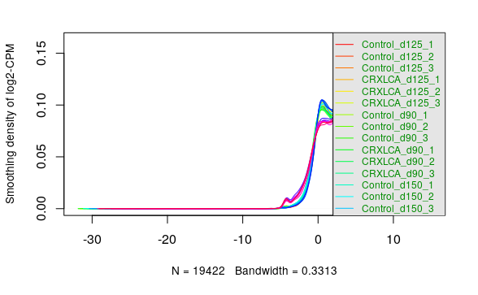

```r
#create legend
legend("topright", colnames(data2plot),
           col=cols, lty=ltys, cex=0.75,
           border ="blue",  text.col = "green4",
           merge = TRUE, bg = "gray90")
```

```r
data2plot <- 0
counts_density <- 0
```

## Part 6: Normalizing the Data

```r
#plotMA(log2(ca125_exp[,c(3,4)]), ylab="M - ratio log expression",
       #main="CA125 + vs - - example")
```

```r
samples <- data.frame(lapply(colnames(CRX_ExperimentRawCountFiltered)[3:28], FUN=function(x){unlist(strsplit(x, split = "\\_"))[c(1, 2, 3)]}))
samples
```

| c..Control....d125....1.. | c..Control....d125....2.. | c..Control....d125....3.. | c..CRXLCA....d125....1.. | c..CRXLCA....d125....2.. | c..CRXLCA....d125....3.. | c..Control....d90....1.. | c..Control....d90....2.. | c..Control....d90....3.. | c..CRXLCA....d90....1.. | c..CRXLCA....d90....2.. | c..CRXLCA....d90....3.. | c..Control....d150....1.. | c..Control....d150....2.. | c..Control....d150....3.. | c..CRXLCA....d150....1.. | c..CRXLCA....d150....2.. | c..CRXLCA....d150....3.. | c..Control....d200....1.. | c..Control....d200....2.. | c..Control....d200....3.. | c..Control....d200....4.. | c..CRXLCA....d200....1.. | c..CRXLCA....d200....2.. | c..CRXLCA....d200....3.. | c..CRXLCA....d200....4.. |
| --- | --- | --- | --- | --- | --- | --- | --- | --- | --- | --- | --- | --- | --- | --- | --- | --- | --- | --- | --- | --- | --- | --- | --- | --- | --- |
| Control | Control | Control | CRXLCA | CRXLCA | CRXLCA | Control | Control | Control | CRXLCA | CRXLCA | CRXLCA | Control | Control | Control | CRXLCA | CRXLCA | CRXLCA | Control | Control | Control | Control | CRXLCA | CRXLCA | CRXLCA | CRXLCA |
| d125 | d125 | d125 | d125 | d125 | d125 | d90 | d90 | d90 | d90 | d90 | d90 | d150 | d150 | d150 | d150 | d150 | d150 | d200 | d200 | d200 | d200 | d200 | d200 | d200 | d200 |
| 1 | 2 | 3 | 1 | 2 | 3 | 1 | 2 | 3 | 1 | 2 | 3 | 1 | 2 | 3 | 1 | 2 | 3 | 1 | 2 | 3 | 4 | 1 | 2 | 3 | 4 |

```r
colnames(samples) <- colnames(CRX_ExperimentRawCountFiltered)[3:28]
rownames(samples) <- c("condition", "time","patient")
samples <- data.frame(t(samples))
samples
```

|  | condition | time | patient |
| --- | --- | --- | --- |
| Control_d125_1 | Control | d125 | 1 |
| Control_d125_2 | Control | d125 | 2 |
| Control_d125_3 | Control | d125 | 3 |
| CRXLCA_d125_1 | CRXLCA | d125 | 1 |
| CRXLCA_d125_2 | CRXLCA | d125 | 2 |
| CRXLCA_d125_3 | CRXLCA | d125 | 3 |
| Control_d90_1 | Control | d90 | 1 |
| Control_d90_2 | Control | d90 | 2 |
| Control_d90_3 | Control | d90 | 3 |
| CRXLCA_d90_1 | CRXLCA | d90 | 1 |

[output cut: 16 more lines]

## Part 7: Data after Normalization

```r
filtered_data_matrix <- as.matrix(CRX_ExperimentRawCountFiltered[,3:28])
rownames(filtered_data_matrix) <- CRX_ExperimentRawCountFiltered$ens.id
d = edgeR::DGEList(counts=filtered_data_matrix, group=samples$condition)
d = edgeR::calcNormFactors(d)
normalized_counts <- edgeR::cpm(d)
normalized_counts
```

[output not shown]

[output cut: 219 more lines]

[output not shown]

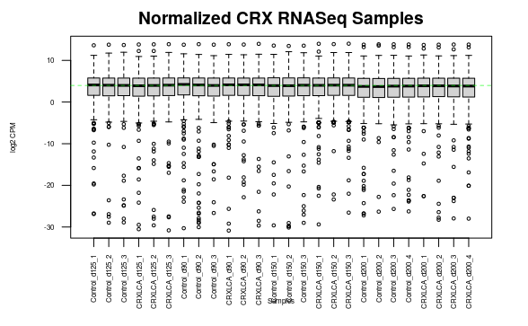

```r
data2plot <- log2(edgeR::cpm(normalized_counts))
boxplot(data2plot, xlab = "Samples", ylab = "log2 CPM",
        las = 2, cex = 0.5, cex.lab = 0.5,
        cex.axis = 0.5, main = "Normalized CRX RNASeq Samples")
#draw the median on each box plot
abline(h = median(apply(data2plot, 2, median)),
       col = "green", lwd = 0.6, lty = "dashed")
```

```r
counts_density <- apply(log2(edgeR::cpm(normalized_counts)),
                        2, density)
  #calculate the limits across all the samples
xlim <- 0; ylim <- 0
for (i in 1:length(counts_density))
  {
    xlim <- range(c(xlim, counts_density[[i]]$x));
    ylim <- range(c(ylim, counts_density[[i]]$y))
  }
cols <- rainbow(length(counts_density))
ltys <- rep(1, length(counts_density))
#plot the first density plot to initialize the plot
plot(counts_density[[1]], xlim=xlim, ylim=ylim, type="n",
         ylab="Smoothing density of log2-CPM Normalized",
         main="", cex.lab = 0.85)
#plot each line
for (i in 1:length(counts_density)) lines(counts_density[[i]], col=cols[i], lty=ltys[i])
```

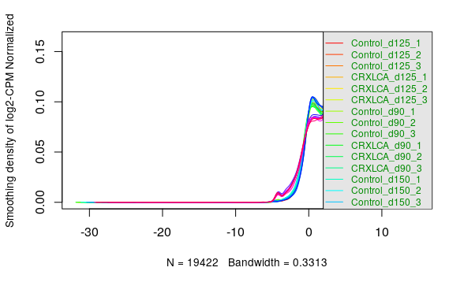

```r
#create legend
legend("topright", colnames(data2plot),
           col=cols, lty=ltys, cex=0.75,
           border ="blue",  text.col = "green4",
           merge = TRUE, bg = "gray90")
```

## Part 8: Dispersion

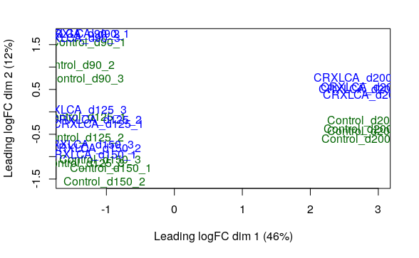

```r
limma::plotMDS(d, labels=rownames(samples), col = c("darkgreen","blue")[factor(samples$condition)])
```

## Part 9: Mapping the data

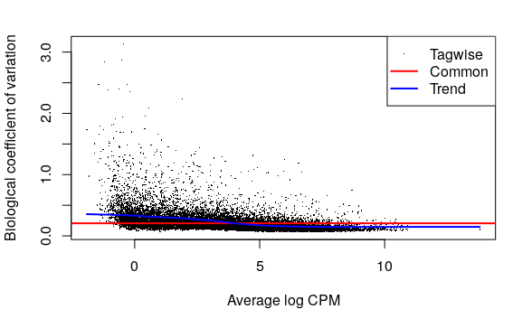

```r
model_design <- model.matrix(~samples$patient
                             + samples$condition+samples$time+0)
d <- edgeR::estimateDisp(d, model_design)
edgeR::plotBCV(d,col.tagwise = "black",col.common = "red",)
```

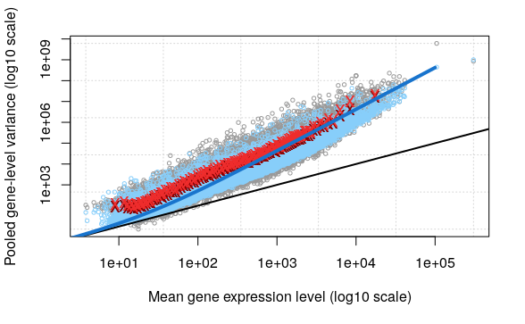

```r
edgeR::plotMeanVar(d, show.raw.vars = TRUE,
            show.tagwise.vars= TRUE,
            NBline= TRUE, show.ave.raw.vars = TRUE,
            show.binned.common.disp.vars = TRUE)
```

```r
biomaRt::listMarts()
```

| biomart | version |
| --- | --- |
| ENSEMBL_MART_ENSEMBL | Ensembl Genes 105 |
| ENSEMBL_MART_MOUSE | Mouse strains 105 |
| ENSEMBL_MART_SNP | Ensembl Variation 105 |
| ENSEMBL_MART_FUNCGEN | Ensembl Regulation 105 |

```r
ensemblMart <- biomaRt::useMart("ensembl")
datasets <- biomaRt::listDatasets(ensemblMart)
knitr::kable(head(datasets), format = "html")
```

| dataset | description | version |
| --- | --- | --- |
| abrachyrhynchus_gene_ensembl | Pink-footed goose genes (ASM259213v1) | ASM259213v1 |
| acalliptera_gene_ensembl | Eastern happy genes (fAstCal1.2) | fAstCal1.2 |
| acarolinensis_gene_ensembl | Green anole genes (AnoCar2.0v2) | AnoCar2.0v2 |
| acchrysaetos_gene_ensembl | Golden eagle genes (bAquChr1.2) | bAquChr1.2 |
| acitrinellus_gene_ensembl | Midas cichlid genes (Midas_v5) | Midas_v5 |
| amelanoleuca_gene_ensembl | Giant panda genes (ASM200744v2) | ASM200744v2 |

```r
knitr::kable(head(datasets[grep(datasets$dataset,
                  pattern = "sapiens"),]),format = "html")
```

|  | dataset | description | version |
| --- | --- | --- | --- |
| 80 | hsapiens_gene_ensembl | Human genes (GRCh38.p13) | GRCh38.p13 |

```r
ensemblDataSet <-  biomaRt::useDataset("hsapiens_gene_ensembl", mart=ensemblMart)
```

```r
dim(biomaRt::listFilters(ensemblDataSet))
```

```
[1] 439   2
```

```r
knitr::kable(biomaRt::listFilters(ensemblDataSet)[1:10,1:2], type="html")
```

| name | description |
| --- | --- |
| chromosome_name | Chromosome/scaffold name |
| start | Start |
| end | End |
| strand | Strand |
| chromosomal_region | e.g. 1:100:10000:-1, 1:100000:200000:1 |
| with_biogrid | With BioGRID Interaction data, The General Repository for Interaction Datasets ID(s) |
| with_ccds | With CCDS ID(s) |
| with_chembl | With ChEMBL ID(s) |
| with_dbass3 | With DataBase of Aberrant 3’ Splice Sites ID(s) |
| with_dbass5 | With DataBase of Aberrant 5’ Splice Sites ID(s) |

```r
biomart_human_filters <- biomaRt::listFilters(ensemblDataSet)
knitr::kable(biomart_human_filters[grep(biomart_human_filters$name, pattern="ensembl"),], format="html")
```

|  | name | description |
| --- | --- | --- |
| 51 | ensembl_gene_id | Gene stable ID(s) [e.g. ENSG00000000003] |
| 52 | ensembl_gene_id_version | Gene stable ID(s) with version [e.g. ENSG00000000003.15] |
| 53 | ensembl_transcript_id | Transcript stable ID(s) [e.g. ENST00000000233] |
| 54 | ensembl_transcript_id_version | Transcript stable ID(s) with version [e.g. ENST00000000233.10] |
| 55 | ensembl_peptide_id | Protein stable ID(s) [e.g. ENSP00000000233] |
| 56 | ensembl_peptide_id_version | Protein stable ID(s) with version [e.g. ENSP00000000233.5] |
| 57 | ensembl_exon_id | Exon ID(s) [e.g. ENSE00000000003] |

```r
knitr::kable(biomaRt::listAttributes(ensemblDataSet)[1:10,1:2], type="html")
```

| name | description |
| --- | --- |
| ensembl_gene_id | Gene stable ID |
| ensembl_gene_id_version | Gene stable ID version |
| ensembl_transcript_id | Transcript stable ID |
| ensembl_transcript_id_version | Transcript stable ID version |
| ensembl_peptide_id | Protein stable ID |
| ensembl_peptide_id_version | Protein stable ID version |
| ensembl_exon_id | Exon stable ID |
| description | Gene description |
| chromosome_name | Chromosome/scaffold name |
| start_position | Gene start (bp) |

```r
knitr::kable(biomaRt::searchAttributes(mart = ensemblDataSet, 'hgnc') , format="html")
```

|  | name | description | page |
| --- | --- | --- | --- |
| 64 | hgnc_id | HGNC ID | feature_page |
| 65 | hgnc_symbol | HGNC symbol | feature_page |
| 95 | hgnc_trans_name | Transcript name ID | feature_page |

```r
knitr::kable(biomaRt::searchAttributes(mart = ensemblDataSet, 'ensembl|hgnc')[1:12,], format="html")
```

|  | name | description | page |
| --- | --- | --- | --- |
| 1 | ensembl_gene_id | Gene stable ID | feature_page |
| 2 | ensembl_gene_id_version | Gene stable ID version | feature_page |
| 3 | ensembl_transcript_id | Transcript stable ID | feature_page |
| 4 | ensembl_transcript_id_version | Transcript stable ID version | feature_page |
| 5 | ensembl_peptide_id | Protein stable ID | feature_page |
| 6 | ensembl_peptide_id_version | Protein stable ID version | feature_page |
| 7 | ensembl_exon_id | Exon stable ID | feature_page |
| 64 | hgnc_id | HGNC ID | feature_page |
| 65 | hgnc_symbol | HGNC symbol | feature_page |
| 95 | hgnc_trans_name | Transcript name ID | feature_page |
| 204 | ensembl_gene_id | Gene stable ID | structure |
| 205 | ensembl_gene_id_version | Gene stable ID version | structure |

```r
conversion_stash <- "CRX_id_conversion.rds"
if(file.exists(conversion_stash)){
  CRX_id_conversion <- readRDS(conversion_stash)
} else {
  CRX_id_conversion <- biomaRt::getBM(attributes = c("ensembl_gene_id","hgnc_symbol"),
                            filters = c("ensembl_gene_id"),
                            values = CRX_ExperimentRawCountFiltered$ens.id,
                            mart = ensemblDataSet)
  saveRDS(CRX_id_conversion, conversion_stash)
}
```

```r
length(
  which(
    rownames(normalized_counts) %in% CRX_id_conversion$ensembl_gene_id
      ))
```

```
[1] 19332
```

```r
nrow(normalized_counts)
```

```
[1] 19422
```

```r
nrow(normalized_counts) - length(which(rownames(normalized_counts) %in% CRX_id_conversion$ensembl_gene_id))
```

```
[1] 90
```

```r
normalized_counts_annot <- merge(CRX_id_conversion, normalized_counts,
                                 by.x = 1, by.y = 0, all.y=TRUE)
knitr::kable(normalized_counts_annot[1:5,1:5],type = "html")
```

| ensembl_gene_id | hgnc_symbol | Control_d125_1 | Control_d125_2 | Control_d125_3 |
| --- | --- | --- | --- | --- |
| ENSG00000000003 | TSPAN6 | 80.530063 | 91.934087 | 66.124192 |
| ENSG00000000419 | DPM1 | 24.979853 | 29.628519 | 30.503261 |
| ENSG00000000457 | SCYL3 | 24.105965 | 26.667433 | 24.053570 |
| ENSG00000000460 | C1orf112 | 10.872027 | 12.830529 | 12.099437 |
| ENSG00000000971 | CFH | 4.515495 | 1.481424 | 2.640055 |

```r
# this is the ones that are null
ensembl_id_missing_gene <- normalized_counts_annot$ensembl_gene_id[
  which(is.na(normalized_counts_annot$hgnc_symbol))]
length(ensembl_id_missing_gene)
```

```
[1] 90
```

```r
knitr::kable(normalized_counts_annot[which(is.na(normalized_counts_annot$hgnc_symbol))[1:5],1:5], type="html")
```

|  | ensembl_gene_id | hgnc_symbol | Control_d125_1 | Control_d125_2 | Control_d125_3 |
| --- | --- | --- | --- | --- | --- |
| 4077 | ENSG00000116883 | NA | 22.3735672 | 19.6192730 | 19.2045043 |
| 5411 | ENSG00000130489 | NA | 5.0837175 | 3.6353925 | 3.2938271 |
| 5450 | ENSG00000130723 | NA | 582.1144191 | 418.5338560 | 470.2142333 |
| 8363 | ENSG00000154537 | NA | 2.9623820 | 2.0541006 | 1.9770625 |
| 9286 | ENSG00000163009 | NA | 0.4667442 | 0.3346634 | 0.5171046 |

```r
old_mapping <- merge(CRX_ExperimentRawCountFiltered[,1:2],data.frame(ensembl_id_missing_gene),all.y = TRUE, by.x=1, by.y=1)
```

```r
knitr::kable(old_mapping[1:10,], type="html")
```

| ens.id | gene.id |
| --- | --- |
| ENSG00000116883 | AL591845.1 |
| ENSG00000130489 | SCO2 |
| ENSG00000130723 | PRRC2B |
| ENSG00000154537 | FAM27C |
| ENSG00000163009 | C2orf48 |
| ENSG00000184258 | CDR1 |
| ENSG00000186842 | LINC00846 |
| ENSG00000204282 | TNRC6C-AS1 |
| ENSG00000206532 | AC117402.1 |
| ENSG00000213240 | AC239799.1 |

```r
# this is the number of times the hgnc symbol to the number of times they occurs
occurences <- data.frame(table(CRX_id_conversion$hgnc_symbol))
# showing the one that occurs more than once
occurences[occurences$Freq > 1,]
```

|  | Var1 | Freq |
| --- | --- | --- |
| 1 |  | 2281 |
| 2086 | CCDC39 | 2 |
| 7494 | LINC01238 | 2 |
| 10902 | POLR2J3 | 2 |
| 10903 | POLR2J4 | 2 |
| 14366 | TBCE | 2 |

## Part 10 interpreting the data

First of all, I want to clarify that although the associated publication has both bulk RNA-seq and single cell RNA-seq, the dataset series GSE153099 is the one for single cell (it specifically mentions this in its overall design section on GEO) and the dataset series GSE152939 is bulk RNA-seq, which contain 2 data set separate by which mutation is being tested on.

In simple terms, leber congenital amaurosis (LCA) is an eye disease that causes vision loss, most cases of LCA are caused by mutation(s) in Cone-rod homeobox (CRX). Normally LCA is a autosomal recessive disease, but some of the mutation in some genes can make it autosomal dominant, CRX is an example of such gene.

1. What are the control and test conditions of the dataset?

   The test condition is a retinal organoid derived from a induced pluripotent stem cells which is derived from a LCA-dominant patient with a mutation in CRX (specifically I138fs48). The control is another retinal organoid derived from induced pluripotent stem cells which is the healthy parent of the patient.
2. Why is the dataset of interest to you?

   I was initially interested because it talks about gene therapy, which from my perspective is something that directly remove the cause of the disease, by changing the gene. It is the ultimate “treat the cause, not the symptom” treatment. As I was reading the paper, I was amazed that it has so many different things, like organoids, IPSC, bulk RNA-seq, single cell RNA-seq. Maybe it is just me, but I have never seems these terms mention in the same paper.
3. Were there expression values that were not unique for specific genes?

   Yes, for the HGNC symbols, CCDC3, LINC01238, POLR2J3, POLR2J4, TBCE, they each map to 2 ensemble ids.
4. Were there expression values that could not be mapped to current HUGO symbols?

   Yes, there was about 90+2281=2371 ensemble ids that is like this. (This comes from 90 ensemble ids that are not in the mapping and 2281 where the corresponding HGNC symbol is empty) There are 19422 ensemble ids, only 17051 are mapped to current HUGO symbols, this is not too surprising as the associated publication was published on January 28, 2021, and the dataset was last updated on GEO on February 17, 2021 and it is February 15, 2022 at the time of writing this report, so the dataset was not too outdated.
5. How many outliers were removed?

   None, because I do not have any reason to believe a measurement error has occurred. Except from the ones that were remove due to low count.
6. How did you handle replicates?

   As mentioned in control vs test question, we have 1 pairs of parent and child. 3 organoid were each derived from the parent and the child for a total of 6 organoids. Then each organoid was measured at day 90, day 125, day 150, day 200. I think that a different organoid does mean a different biological replicate, though I am not sure in the event that control and test comes from different individuals, does that count as different biological replicates, but if that is the case, then we have 6 biological replicates, else we just have 3. Also, I am almost sure that the retinal organoid from different days are not considered biologically different. For measurement between different organoids, they are unpaired, and the same organoid, paired. I think there are no technical replicates in this file. None of the replicate were outlines, with respect to their own time and condition. Though the day 200 measurement does seems out of place, compare to other day in the MDS plot perhaps some developmental milestones were reached
7. What is the final coverage of your dataset?

   Around 19422 genes after filtering out low counts, but only 17051 are mapped to HGNC symbols.

## Part 11: Citations

Kruczek, K., Qu, Z., Gentry, J., Fadl, B. R., Gieser, L., Hiriyanna, S., Batz, Z., Samant, M., Samanta, A., Chu, C. J., Campello, L., Brooks, B. P., Wu, Z., & Swaroop, A. (2021). Gene Therapy of Dominant CRX-Leber Congenital Amaurosis using Patient Stem Cell-Derived Retinal Organoids. *Stem cell reports*, *16*(2), 252–263. https://doi.org/10.1016/j.stemcr.2020.12.018